# Practical Learning Machine - Prediction Writeup

Bern Reyes

January 28, 2018

### Background

Using devices such as Jawbone Up, Nike FuelBand, and Fitbit it is now possible to collect a large amount of data about personal activity relatively inexpensively. These type of devices are part of the quantified self movement - a group of enthusiasts who take measurements about themselves regularly to improve their health, to find patterns in their behavior, or because they are tech geeks. One thing that people regularly do is quantify how much of a particular activity they do, but they rarely quantify how well they do it. In this project, your goal will be to use data from accelerometers on the belt, forearm, arm, and dumbell of 6 participants. They were asked to perform barbell lifts correctly and incorrectly in 5 different ways. More information is available from the [website here](http://web.archive.org/web/20161224072740/http:/groupware.les.inf.puc-rio.br/har) (see the section on the Weight Lifting Exercise Dataset).

### Data

The training data for this project are available here: https://d396qusza40orc.cloudfront.net/predmachlearn/pml-training.csv

The test data are available here: https://d396qusza40orc.cloudfront.net/predmachlearn/pml-testing.csv

The data for this project come from this source: http://web.archive.org/web/20161224072740/http:/groupware.les.inf.puc-rio.br/har.

### Data Loading and Processing

```r
library(caret)
```

```r
library(rpart)
library(rpart.plot)
library(RColorBrewer)
library(rattle)
library(randomForest)
if (!file.exists("./data")) {
  dir.create("./data")
}
if (!file.exists("./data/pml-training.csv")) {
  url.training <- "https://d396qusza40orc.cloudfront.net/predmachlearn/pml-training.csv"
  download.file(url.training, destfile = "./data/pml-training.csv", method="curl")
}

if (!file.exists("./data/pml-testing.csv")) {
  url.testing <- "https://d396qusza40orc.cloudfront.net/predmachlearn/pml-testing.csv"
  download.file(url.testing, destfile = "./data/pml-testing.csv", method="curl")
}

training <- read.csv("./data/pml-training.csv", na.strings=c("NA","#DIV/0!",""))

#check the observations and variables of the data
dim(training)
```

```
## [1] 19622   160
```

```r
#remove variables with missing values
training <- training[, colSums(is.na(training)) == 0]

names(training)
```

```
##  [1] "X"                    "user_name"            "raw_timestamp_part_1"
##  [4] "raw_timestamp_part_2" "cvtd_timestamp"       "new_window"
##  [7] "num_window"           "roll_belt"            "pitch_belt"
## [10] "yaw_belt"             "total_accel_belt"     "gyros_belt_x"
## [13] "gyros_belt_y"         "gyros_belt_z"         "accel_belt_x"
## [16] "accel_belt_y"         "accel_belt_z"         "magnet_belt_x"
## [19] "magnet_belt_y"        "magnet_belt_z"        "roll_arm"
## [22] "pitch_arm"            "yaw_arm"              "total_accel_arm"
## [25] "gyros_arm_x"          "gyros_arm_y"          "gyros_arm_z"
## [28] "accel_arm_x"          "accel_arm_y"          "accel_arm_z"
## [31] "magnet_arm_x"         "magnet_arm_y"         "magnet_arm_z"
## [34] "roll_dumbbell"        "pitch_dumbbell"       "yaw_dumbbell"
## [37] "total_accel_dumbbell" "gyros_dumbbell_x"     "gyros_dumbbell_y"
## [40] "gyros_dumbbell_z"     "accel_dumbbell_x"     "accel_dumbbell_y"
## [43] "accel_dumbbell_z"     "magnet_dumbbell_x"    "magnet_dumbbell_y"
## [46] "magnet_dumbbell_z"    "roll_forearm"         "pitch_forearm"
## [49] "yaw_forearm"          "total_accel_forearm"  "gyros_forearm_x"
## [52] "gyros_forearm_y"      "gyros_forearm_z"      "accel_forearm_x"
## [55] "accel_forearm_y"      "accel_forearm_z"      "magnet_forearm_x"
## [58] "magnet_forearm_y"     "magnet_forearm_z"     "classe"
```

```r
#remove the first 7 variables that are not useful for the analysis
training <- training[,-(1:7)]
```

There are originally 160 variables, but most of them have missing or invalid values. Also, the first seven columns which are about the timestamp, username and new/num window in the data are not useful for the analysis, thus these were removed from the dataset.

### Data Partitioning

The training dataset was partitioned into two sets, 70% as training data and the remaining 30% as testing data for cross validation.

```r
fortraining <- createDataPartition(training$classe, p=0.7, list=FALSE)
training_data <- training[fortraining,]
testing_data <- training[-fortraining,]
```

### Data Prediction and Modeling

Two methods will be used in this report, Decision Tree and Random Forest. The chosen model after comparing the two models will be used to answer the course project prediction quiz.

## Decision Tree

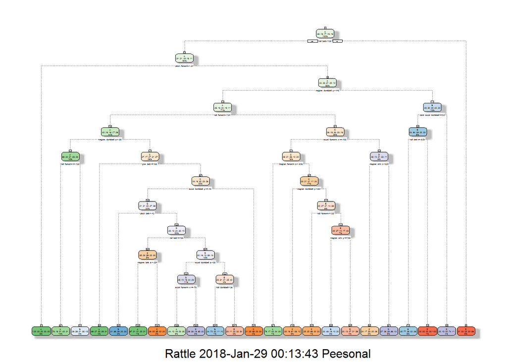

```r
set.seed(100)
dtree <- rpart(classe ~ ., data = training_data, method="class", control = rpart.control(method = "cv", number = 10))
fancyRpartPlot(dtree)
```

```r
predictdtree <- predict(dtree, newdata=testing_data, type="class")
confusionMatrix(predictdtree, testing_data$classe)
```

```
## Confusion Matrix and Statistics
##
##           Reference
## Prediction    A    B    C    D    E
##          A 1532  196   54  115   25
##          B   58  680   78   78   91
##          C   36  150  781   79   88
##          D   39   65   97  585   69
##          E    9   48   16  107  809
##
## Overall Statistics
##
##                Accuracy : 0.7455
##                  95% CI : (0.7341, 0.7565)
##     No Information Rate : 0.2845
##     P-Value [Acc > NIR] : < 2.2e-16
##
##                   Kappa : 0.6763
##  Mcnemar's Test P-Value : < 2.2e-16
##
## Statistics by Class:
##
##                      Class: A Class: B Class: C Class: D Class: E
## Sensitivity            0.9152   0.5970   0.7612  0.60685   0.7477
## Specificity            0.9074   0.9357   0.9274  0.94513   0.9625
## Pos Pred Value         0.7971   0.6904   0.6887  0.68421   0.8180
## Neg Pred Value         0.9642   0.9063   0.9484  0.92465   0.9442
## Prevalence             0.2845   0.1935   0.1743  0.16381   0.1839
## Detection Rate         0.2603   0.1155   0.1327  0.09941   0.1375
## Detection Prevalence   0.3266   0.1674   0.1927  0.14528   0.1681
## Balanced Accuracy      0.9113   0.7664   0.8443  0.77599   0.8551
```

The accuracy of the Decision Tree model is 74.6%.

## Random Forest

```r
set.seed(100)
control <- trainControl(method="cv", 5)
RForest <- train(classe ~ ., data=training_data, method="rf", trControl=control)
RForest
```

```
## Random Forest
##
## 13737 samples
##    52 predictor
##     5 classes: 'A', 'B', 'C', 'D', 'E'
##
## No pre-processing
## Resampling: Cross-Validated (5 fold)
## Summary of sample sizes: 10990, 10988, 10991, 10990, 10989
## Resampling results across tuning parameters:
##
##   mtry  Accuracy   Kappa
##    2    0.9913373  0.9890413
##   27    0.9922108  0.9901458
##   52    0.9855866  0.9817626
##
## Accuracy was used to select the optimal model using the largest value.
## The final value used for the model was mtry = 27.
```

```r
predictRForest <- predict(RForest, testing_data)
confusionMatrix(testing_data$classe, predictRForest)
```

```
## Confusion Matrix and Statistics
##
##           Reference
## Prediction    A    B    C    D    E
##          A 1673    1    0    0    0
##          B    8 1127    4    0    0
##          C    0    6 1016    4    0
##          D    0    0    4  959    1
##          E    0    1    3    4 1074
##
## Overall Statistics
##
##                Accuracy : 0.9939
##                  95% CI : (0.9915, 0.9957)
##     No Information Rate : 0.2856
##     P-Value [Acc > NIR] : < 2.2e-16
##
##                   Kappa : 0.9923
##  Mcnemar's Test P-Value : NA
##
## Statistics by Class:
##
##                      Class: A Class: B Class: C Class: D Class: E
## Sensitivity            0.9952   0.9930   0.9893   0.9917   0.9991
## Specificity            0.9998   0.9975   0.9979   0.9990   0.9983
## Pos Pred Value         0.9994   0.9895   0.9903   0.9948   0.9926
## Neg Pred Value         0.9981   0.9983   0.9977   0.9984   0.9998
## Prevalence             0.2856   0.1929   0.1745   0.1643   0.1827
## Detection Rate         0.2843   0.1915   0.1726   0.1630   0.1825
## Detection Prevalence   0.2845   0.1935   0.1743   0.1638   0.1839
## Balanced Accuracy      0.9975   0.9952   0.9936   0.9954   0.9987
```

The accuracy of the Random Forest model is 99.4% which means that this model yields more accurate result than the Decision Tree. Thus, it will be used for the testing data for course project prediction quiz.

### Prediction using the Random Forest Model to the Testing Data

```r
#Load and clean the testing data
test <- read.csv("./data/pml-testing.csv", na.strings=c("NA","#DIV/0!",""))
test <- test[, colSums(is.na(test)) == 0]
test <- test[,-(1:7)]

#Apply the chosen model
predictTestdata <- predict(RForest, newdata=test)
predictTestdata
```

```
##  [1] B A B A A E D B A A B C B A E E A B B B
## Levels: A B C D E
```

The results above are the answer to the 20-item quiz.